# Data visualization with ggplot2

## Label & Plot Fonts

Note that it is also possible to change the fonts of your plots. If you are on Windows, you may have to install the [**`extrafont`** package](https://github.com/wch/extrafont), and follow the instructions included in the README for this package.

After our manipulations, you may notice that the values on the x-axis are still not properly readable. Let’s change the orientation of the labels and adjust them vertically and horizontally so they don’t overlap. You can use a 90-degree angle, or experiment to find the appropriate angle for diagonally oriented labels using the `hjust` and `vjust` options in the text theme.

The value of `hjust` and `vjust` are defined between 0 and 1.

`angle` controls the angle of the text with the x-axis  
- The angle is defined from x-axis, such that:

```
* angles from 0-90 rotate the text counter-clockwise
* negative angles rotate clockwise (from 0 to -90)
```

An example should make this more clear:

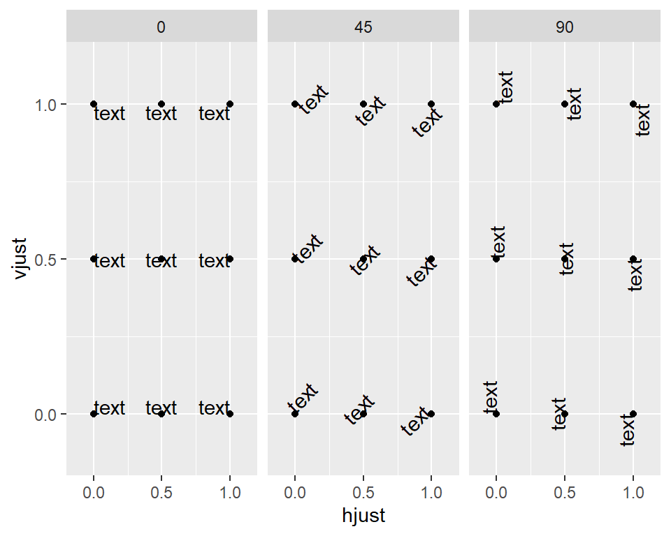

```r
td <- expand.grid(
    hjust = c(0, 0.5, 1),
    vjust = c(0, 0.5, 1),
    angle = c(0, 45, 90),
    text = "text"
)

ggplot(td, aes(x = hjust, y = vjust)) +
    geom_point() +
    geom_text(aes(label = text, angle = angle, hjust = hjust, vjust = vjust)) +
    facet_wrap(vars(angle), nrow = 1) +
    scale_x_continuous(breaks = c(0, 0.5, 1), expand = c(0, 0.2)) +
    scale_y_continuous(breaks = c(0, 0.5, 1), expand = c(0, 0.2))
```

This should give you a rough idea of how you can combine `hjust`, `vjust`, and `angle` together in your text specification to align your axis labels to not overlap!

Let’s give it a try.

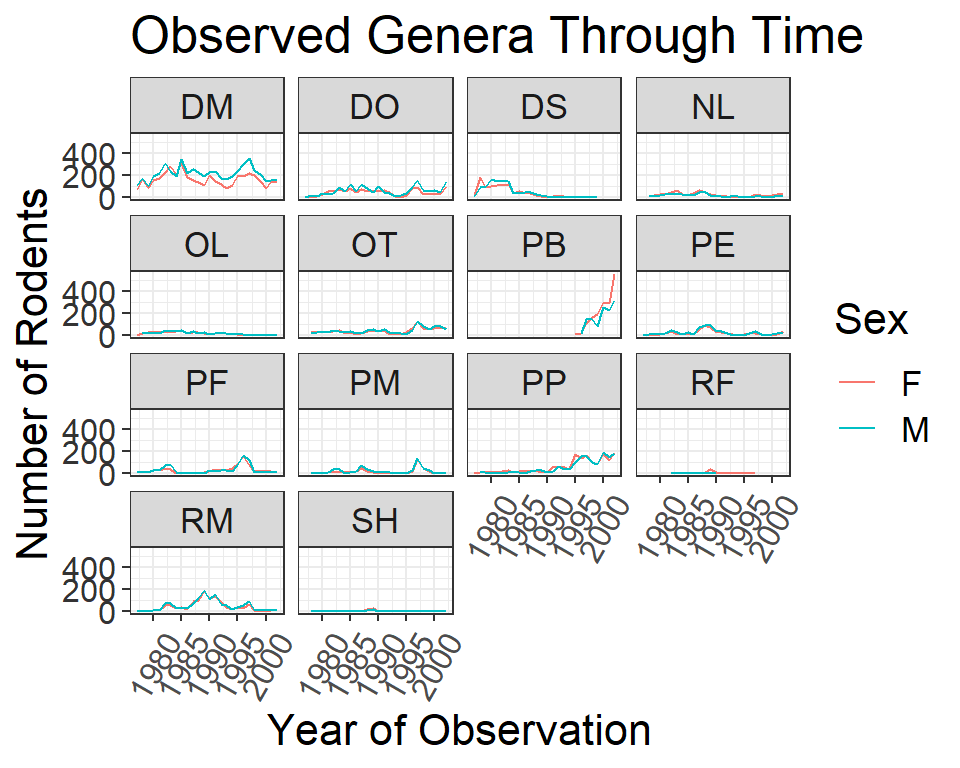

```r
yearly_sex_counts %>%
  ggplot(mapping = aes(x = year, y = n, color = sex)) +
    geom_line() +
    facet_wrap(vars(species_id)) +
    labs(title = "Observed Genera Through Time",
        x = "Year of Observation",
        y = "Number of Rodents",
        color = "Sex") +
    theme_bw() +
    theme(axis.text.x = element_text(size = 12, angle = 60,
                                     hjust = 0.5, vjust = 0.5),
          ## theme specific to x-axis text
          axis.text.y = element_text(colour = "grey20", size = 12),
          ## theme specific to y-axis text
          text = element_text(size = 16))
```

```r
          ## theme for all other text on plot (title, legend, facets, etc.)
```

If you like the changes you created better than the default theme, you can save them as an object to be able to easily apply them to other plots you may create:

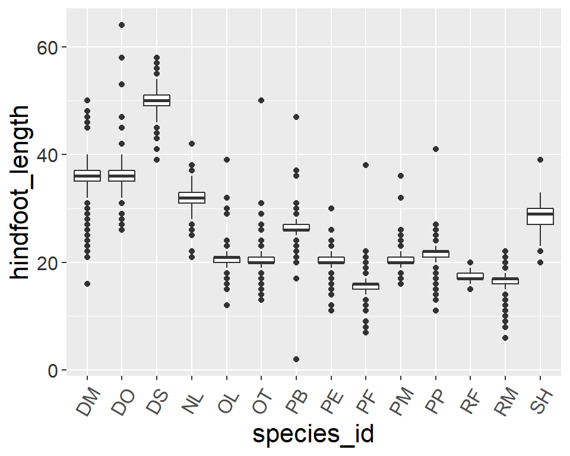

```r
# define custom theme and store in an object to be added to ggplots
grey_theme <- theme(axis.text.x = element_text(size = 12, angle = 60,
                                               hjust = 0.5, vjust = 0.5),
                    axis.text.y = element_text(colour = "grey20", size = 12),
                    text = element_text(size = 16))

# create a boxplot and adds theme object to the plot
surveys_complete %>%
  ggplot(aes(x = species_id, y = hindfoot_length)) +
    geom_boxplot() +
    grey_theme
```

## Changing Colors

The built in `ggplot` color scheme may not be what you were looking for, but don’t worry! There are many other color palettes available to use!

You can change the colors used by `ggplot()` a few different ways.

1. Add the `scale_color_manual()` or `scale_fill_manual()` functions to your plot and directly specify the colors you want to use, by:
- defining a vector of colors right there (e.g. c(“blue”, “black”, “red”, “green”))
- creating a vector of colors and storing it in an object and calling on it (see below)

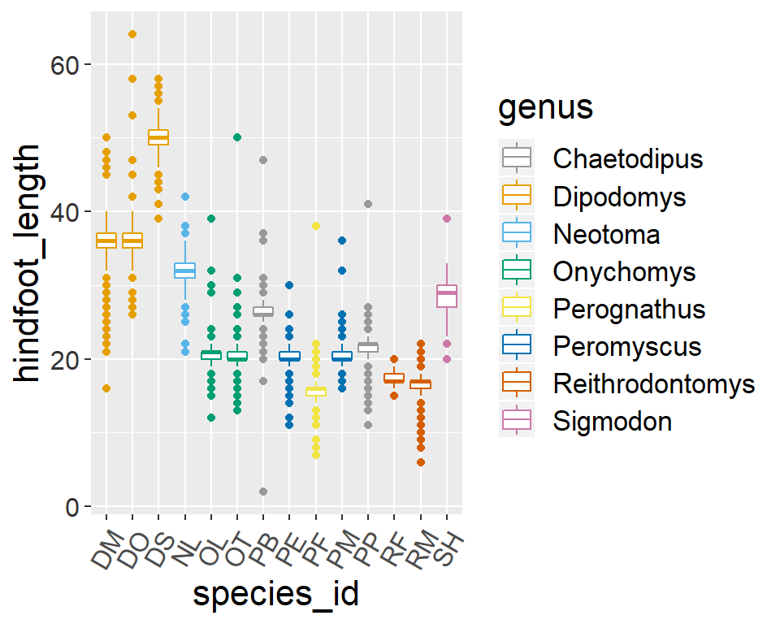

```r
# The palette with grey:
cbPalette_grey <- c("#999999", "#E69F00", "#56B4E9", "#009E73", "#F0E442", "#0072B2", "#D55E00", "#CC79A7")

# The palette with black:
cbbPalette_blk <- c("#000000", "#E69F00", "#56B4E9", "#009E73", "#F0E442", "#0072B2", "#D55E00", "#CC79A7")

surveys_complete %>%
  ggplot(aes(x = species_id, y = hindfoot_length, color = genus)) +
  geom_boxplot() +
  grey_theme +
  scale_color_manual(values = cbPalette_grey)
```

2. Install a package and use it’s available color scales. Popular options include:
- `RColorBrewer`: using `scale_fill_brewer()` or `scale_colour_brewer()`
- `viridis`: using `scale_colour_viridis_d()` for discrete data, `scale_colour_viridis_c()` for continuous data, with an inside argument of `option = <COLOR>` for your chosen color scheme
- `ggsci`: using `scale_color_<PALNAME>()` or `scale_fill_<PALNAME>()`, where you specify the name of the palette you wish to use (e.g. `scale_color_aaas()`)

### Challenge

> With all of this information in hand, please take another five minutes to either improve one of the plots generated in this exercise or create a beautiful graph of your own. Use the RStudio [**`ggplot2`** cheat sheet](https://github.com/rstudio/cheatsheets/raw/master/data-visualization-2.1.pdf) for inspiration. Here are some ideas:
> - See if you can change the thickness of the lines.
> - Can you find a way to change the name of the legend? What about its labels?
> - Try using a different color palette (see http://www.cookbook-r.com/Graphs/Colors_(ggplot2)/).

## Arranging and exporting plots

Faceting is a great tool for splitting one plot into multiple plots, but sometimes you may want to produce a single figure that contains multiple plots using different variables or even different data frames. The **`gridExtra`** package allows us to combine separate ggplots into a single figure using `grid.arrange()`:

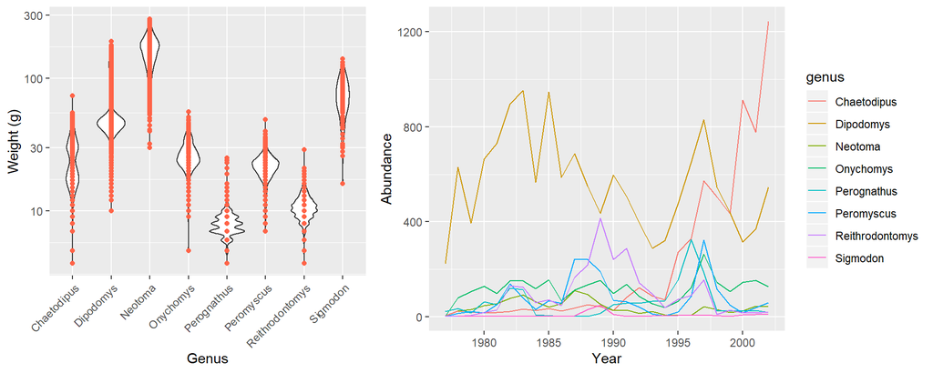

```r
library(gridExtra)

spp_weight_boxplot <- surveys_complete %>%
  ggplot(aes(x = genus, y = weight)) +
  geom_violin() +
  geom_point(color = "tomato") +
  scale_y_log10() +
  labs(x = "Genus", y = "Weight (g)") +
  theme(axis.text.x = element_text(angle = 45, hjust = 1))

spp_count_plot <- yearly_counts %>%
  ggplot(aes(x = year, y = n, color = genus)) +
  geom_line() +
  labs(x = "Year", y = "Abundance")

grid.arrange(spp_weight_boxplot, spp_count_plot, ncol = 2, widths = c(4, 6))
```

```r
## nrow and ncol specify how many rows/columns you want the arranged plots to be in
## widths specify what proportion of the overall plotting area each plot takes up
```

In addition to the `ncol` and `nrow` arguments, used to make simple arrangements, there are tools for [constructing more complex layouts](https://cran.r-project.org/web/packages/gridExtra/vignettes/arrangeGrob.html).

For more assistance arranging plots with `grid.arrage()` I find the following vignette **very** helpful!

https://cran.r-project.org/web/packages/egg/vignettes/Ecosystem.html

# Exporting Plots

After creating your plot, you can save it to a file in your favorite format. The Export tab in the **Plot** pane in RStudio will save your plots at low resolution, which will not be accepted by many journals and will not scale well for posters.

Instead, use the `ggsave()` function, which allows you easily change the dimension and resolution of your plot by adjusting the appropriate arguments:

- `width` and `height`: adjust the total plot size in units (“in”, “cm”, or “mm”)
  - If units are not specified, default is inches.
- `dpi`: adjusts the plot resolution. This accepts a string or numeric input:
  - “retina” (320)
  - “print” (300)
  - “screen” (72)

Make sure you have the `fig/` folder in your working directory.

```r
my_plot <- ggplot(data = yearly_sex_counts,
                  mapping = aes(x = year, y = n, color = sex)) +
              geom_line() +
              facet_wrap(vars(species_id)) +
              labs(title = "Observed genera through time",
                    x = "Year of observation",
                    y = "Number of individuals") +
              theme_bw() +
              theme(axis.text.x = element_text(colour = "grey20", size = 12,
                                               angle = 90, hjust = 0.5,
                                               vjust = 0.5),
                    axis.text.y = element_text(colour = "grey20", size = 12),
                    text = element_text(size = 16))

ggsave("fig/yearly_sex_counts.png", my_plot, width = 15, height = 10)

# This also works for grid.arrange() plots
combo_plot <- grid.arrange(spp_weight_boxplot, spp_count_plot,
                           ncol = 2, widths = c(4, 6))

ggsave("fig/combo_plot_abun_weight.png", combo_plot, width = 10, dpi = 300)
```

> Note: The parameters `width` and `height` also determine the font size in the saved plot.

### Final Challenge

> With all of this information in hand, please take another five minutes to either improve one of the plots generated in this exercise or create a beautiful graph of your own. Use the RStudio ggplot2 cheat sheet for inspiration: https://www.rstudio.com/wp-content/uploads/2015/08/ggplot2-cheatsheet.pdf

Workshop build on: 2019-11-12 13:34:22